# SFJD 2014 Mean

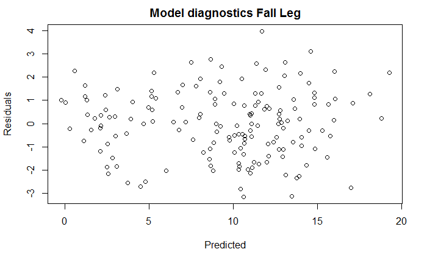

```r
  plot(pred.y, mod$residuals, main="Model diagnostics Fall Leg", xlab="Predicted", ylab="Residuals")
```

write out predicted, coeffs, & metrics

```r
  pred.out <- matrix(nrow=length(pred.y), ncol=5)
  pred.out[,1] <- y
  pred.out[,2] <- pred.y
  pred.out[,3] <- z
  pred.out[,4] <- "fall"
  pred.out[,5] <- yearPath

  write.table (x=pred.out,append=T,row.names=F,file=paste0("jk_pred_v_y_", var, "_", basin, "_", yearPath, "_sp_fall.csv"),sep = ",", col.names=F)

  coeffs_out[2,1] <- coeffs[1,1]
  coeffs_out[2,2] <- coeffs[2,1]
  coeffs_out[2,3] <- coeffs[3,1]
  coeffs_out[2,4] <- coeffs[4,1]
  coeffs_out[2,5] <- coeffs[5,1]

  metrics_out[2,1] <- sum_mod$adj.r.squared
  metrics_out[2,2] <- post_mod$sigma
  metrics_out[2,3] <- p2$val[5]
  metrics_out[2,4] <- RMSEP
  metrics_out[2,5] <- length(unique(data.fall$SiteName))
  metrics_out[2,6] <- length(y)

  write.table(x=coeffs_out, append=F,row.names=T, file = paste0("All_data_", basin, "_", yearPath, "_mod_coeffs_", var, ".csv"), sep = ",", col.names=T)

  write.table(x=metrics_out, append=F,row.names=T, file = paste0("All_data_", basin, "_", yearPath, "_mod_metrics_", var, ".csv"), sep = ",", col.names=T)

  write.table(x=metrics_out, append=F,row.names=T, file = paste0(metricPath, yearPath, "_temp_CHaMP/model_metrics/","All_data_", basin, "_", yearPath, "_mod_metrics_", var, ".csv"), sep = ",", col.names=NA)
```

plot the full year of predicted v observed

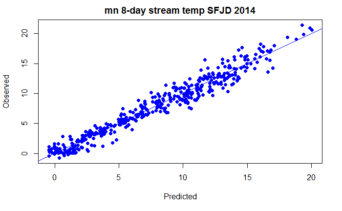

```r
  pred.y <- read.csv(paste0("jk_pred_v_y_", var, "_", basin, "_", yearPath, "_sp_fall.csv"), stringsAsFactors = FALSE, header = FALSE)
  colnames(pred.y) <- c("Y", "PredY", "JulDay", "Season", "Year")

  {plot(pred.y$PredY, pred.y$Y, pch=16, col="blue", main=paste0(var, " 8-day stream temp ", basin, " ", yearPath), xlab="Predicted", ylab="Observed")
  abline(0,1)
  abline(lm(pred.y$Y~ pred.y$PredY), col="blue")}
```

full year fit metrics

```r
  fit <- lm(pred.y$Y~ pred.y$PredY)

  summary(fit)
```

```
Call:
lm(formula = pred.y$Y ~ pred.y$PredY)

Residuals:
    Min      1Q  Median      3Q     Max
-3.1403 -0.6888  0.0348  0.6946  3.9748

Coefficients:
              Estimate Std. Error t value Pr(>|t|)
(Intercept)  2.185e-14  9.654e-02    0.00        1
pred.y$PredY 1.000e+00  1.058e-02   94.52   <2e-16 ***
---
Signif. codes:  0 ‘***’ 0.001 ‘**’ 0.01 ‘*’ 0.05 ‘.’ 0.1 ‘ ’ 1

Residual standard error: 1.102 on 431 degrees of freedom
Multiple R-squared:  0.954, Adjusted R-squared:  0.9539
F-statistic:  8935 on 1 and 431 DF,  p-value: < 2.2e-16
```

This part applies the model coefficients to the LST to generate 8-day temp estimates

```r
  LST.elev <- merge(LST.in, elev.in, by = "RCAID")
```

```
Error in fix.by(by.y, y) : 'by' must specify a uniquely valid column
```

Plot some reaches to take a peek

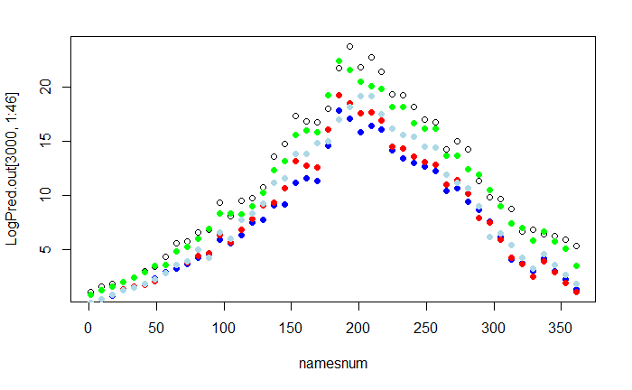

```r
  {plot(namesnum, LogPred.out[3000,1:46])
  points(namesnum, LogPred.out[1000, 1:46], pch=16, col="blue")
  points(namesnum, LogPred.out[1234, 1:46], pch=16, col="green")
  points(namesnum, LogPred.out[562, 1:46], pch=16, col="red")
  points(namesnum, LogPred.out[800, 1:46], pch=16, col="lightblue")}
```

```r
NA
```

This parts formats the error by day/site info

```r
  Log.in <- read.csv(paste0("../", basin, "_logger_8D_", yearPath, ".csv"), stringsAsFactors = FALSE)
```

```
cannot open file '../SFJD_logger_8D_2014.csv': No such file or directoryError in file(file, "rt") : cannot open the connection
```

Geospatial data output

```r
  network <- readOGR(dsn=".", layer = netname)
```

```
Z-dimension discarded
```

Animation output

```r
  seis = c("#AA0000", "#D00000", "#F70000", "#FF1D00", "#FF4400", "#FF6A00", "#FF9000", "#FFB700", "#FFDD00", "#FFE200", "#BDFF0C", "#73FF1A", "#3FFA36", "#16F45A", "#00D08B", "#0087CD", "#0048FA", "#0024E3")
  seis <- rev(seis)

  var <- "mn"
  names.out <- colnames(network@data[3:48])
  namesnum <- as.numeric(gsub(paste0("Tmn", "_", yrPath, "_"), "", colnames(network@data[3:48])))
  means <- colMeans(network@data[3:48], na.rm = TRUE)
  SDs <- colStdevs(network@data[3:48], na.rm = TRUE)
  yplus <- means + SDs
  yminus <- means - SDs
  df <- data.frame(means=means, SDs=SDs, names=namesnum)
  sequ <- c(1:46)
  namer <- sprintf('%03d', sequ)
  fix4 <- classIntervals(means, n = 10, style = "fixed",fixedBreaks=c(-1,2,4,6,8,10,12,14,16,18))
  fix4.colors <- findColours(fix4,pal=seis)

  for (i in 3:48)
    {

      namey <- gsub(paste0("T", var, "_", yrPath, "_"), "", colnames(network@data)[i])

      filename <- paste0(modelPath, "/graphics/", namer[i-2], ".png", sep="")
      png(filename=filename, res = 300, width = 1500, height = 1500, units = "px", bg="black")

      fix3 <- classIntervals(network@data[,i], n = 11, style = "fixed",fixedBreaks=c(-1,2,4,6,8,10,12,14,16,18,20))
      fix3.colors <- findColours(fix3,pal=seis)

      # cexEr <-ifelse(abs(error_pts@data[,i]) == 0, 0,
      #                ifelse(abs(error_pts@data[,i])>0 & error_pts@data[,i-1]<1, 0.5,
      #                       ifelse(abs(error_pts@data[,i])>1 & error_pts@data[,i-1]<2, 0.75,
      #                              ifelse(abs(error_pts@data[,i])>2 & error_pts@data[,i]<3, 1.0,
      #                                     ifelse(abs(error_pts@data[,i])>3, 1.25,
      #                                            ifelse(abs(error_pts@data[,i])== NA, 0, NA))))))
      #
      plot(network, col=fix3.colors, bg="black", fg="white")
      # points(error_pts, pch=16, col="gray40", cex=cexEr)

    legend(x=grconvertX(c(0.88, 0.95), from='npc'),
             y=grconvertY(c(0.35, 0.55), from='npc'), fill = attr(fix3.colors, "palette"), title="8-day Mn (°C)", legend = c("0-2","2-4","4-6","6-8","8-10","10-12","12-14","14-16","16-18","18+"), bty = "n", cex=.5, inset=c(.1,0), text.col="white");
      # legend(x=grconvertX(c(0.02, 0.25), from='npc'),
      #        y=grconvertY(c(0.3, 0.5), from='npc'),, title="Model error (°C)", legend = c("0-1","1-2","2-3","3+"), bty = "n", pch=16, pt.cex=c(0.5, 0.75, 1.0, 1.25), col = "gray40", cex=.5, text.col="white");
      #

      title(paste0(longBasin, " 8-day ", var, " ", yearPath, " (°C)"), line=-0.9, adj=.80, col.main="white", col.sub="white", outer=FALSE, cex.main=0.5, cex.sub=0.5)
      mtext(paste0("Julian Day ", namey),side =1, outer=TRUE, line=-4, col="white", cex=.5)
   tmp2 <- subplot(
        plot(namesnum[1:(i-2)], means[1:(i-2)], col=fix4.colors, pch=16, bty="n", xlim=c(0,360), ylim=c(0,20), cex.main=.8, main="Basin mean (+/-SD)", adj=0, xlab='',ylab='', col.lab="white", cex.axis=0.5, cex.lab = 0.25, col.axis="white", col.main = "white", bg="black"),
        x=grconvertX(c(0.02,0.45), from='npc'),
        y=grconvertY(c(0.02, 0.20), from='npc'),
        size=c(1,1.5), vadj=0.5, hadj=0.5,
        pars=list( mar=c(0,0,0,0)+0.1, cex=0.5))
      op <- par(no.readonly=TRUE)
      par(tmp2)
      arrows(namesnum[1:(i-2)], yplus[1:(i-2)], namesnum[1:(i-2)], yminus[1:(i-2)], length=0, lwd=5, code=3, lend=0, col="gray20")
      par(op)
      tmp2 <- subplot(
        plot(namesnum[1:(i-2)], means[1:(i-2)], col=fix4.colors, pch=16, bty="n", xlim=c(0,360), ylim=c(0,20), cex.main=.8, main="Basin mean (+/-SD)", adj=0, xlab='',ylab='', col.lab="white", cex.axis=0.5, cex.lab = 0.25, col.axis="white", col.main = "white", bg="black"),
        x=grconvertX(c(0.02,0.45), from='npc'),
        y=grconvertY(c(0.02, 0.20), from='npc'),
        size=c(1,1.5), vadj=0.5, hadj=0.5,
        pars=list( mar=c(0,0,0,0)+0.1, cex=0.5))

      dev.off()
    }
```

```
Error in classIntervals(network@data[, i], n = 11, style = "fixed", fixedBreaks = c(-1,  :
  single unique value
```

This system call builds an mpeg out of the still graphics

```r
setwd(paste0(modelPath, "/graphics/"))

  system('"C:/Program Files/ImageMagick-7.0.1-Q16/convert.exe" -delay 20 -morph 3 *.png SFJD_2014_8D_Mn.mpeg')
```

This part generates the project.rs.xml file

```r
Realizguid = UUIDgenerate(F)
#now <- Sys.Date()
now <- "2016-03-02"
```

Start writing project.rs.xml file here

```r
cat("", file=paste(modelPath,"project.rs.xml",sep=""))
cat(paste("","<?xml version=\"1.0\" encoding=\"utf-8\"?>
<Project xmlns:xsi=\"http://www.w3.org/2001/XMLSchema-instance\"
  xsi:noNamespaceSchemaLocation=\"https://raw.githubusercontent.com/Riverscapes/Program/master/Project/XSD/V1/Project.xsd\">
  <Name>stream_temperature_project</Name>
  <ProjectType>STREAMTEMP",capVar,"</ProjectType>
  <MetaData>
    <!--This first metadata exists only to place this project in the riverscapes project-->
    <Meta name=\"HUCID\">17060201</Meta>
        <Meta name=\"Region\">CRB</Meta>
    <Meta name=\"Watershed\">",nameBasin,"</Meta>
  </MetaData>

  <Inputs>
  </Inputs>
  <Realizations>
    <StreamTemperature guid=\"",Realizguid,"\" id=\"streamtemp\" dateCreated=\"",now,"\" productVersion=\"1.0\">
      <Name>Stream Temperature for ",nameBasin, " ",yearPath,"</Name>
      <MetaData>
        <!--This next metadata relates to this particular realization-->
        <Meta name=\"MODIS_dataset\">MOD11A2v005</Meta>
        <Meta name=\"EOSDIS\">https://reverb.echo.nasa.gov/reverb/</Meta>
        <Meta name=\"Logger_data_source\">www.champmonitoring.org</Meta>
        <Meta name=\"Code_wiki\">https://github.com/SouthForkResearch/StreamTemperature/wiki</Meta>
      </MetaData>
      <Analyses>
        <Analysis>
          <Name>Stream Temp Analysis</Name>
          <Outputs>
            <CSV id=\"coeffs\">
              <Name>Model_coefficients</Name>
              <Path>All_data_",basin,"_",yearPath,"_mod_coeffs_",var,".csv</Path>
              <MetaData>
                <Meta name=\"description\">Parameter coefficients for the final model</Meta>
              </MetaData>
            </CSV>
            <CSV id=\"metrics\">
              <Name>Model_metrics</Name>
              <Path>All_data_",basin,"_",yearPath,"_mod_metrics_",var,".csv</Path>
              <MetaData>
                <Meta name=\"description\">Model quality metrics</Meta>
              </MetaData>
            </CSV>
            <CSV id=\"error\">
              <Name>Model_error</Name>
              <Path>Error_",basin,"_",yearPath,"_8D_",var,".csv</Path>
              <MetaData>
                <Meta name=\"description\">Model estimation error for each 8-day period by site</Meta>
              </MetaData>
            </CSV>
            <CSV id=\"estimates\">
              <Name>Model_data_prediction</Name>
              <Path>jk_pred_v_y_",var, "_", basin,"_",yearPath,"_sp_fall.csv</Path>
              <MetaData>
                <Meta name=\"description\">Jack-knifed temperature estimate for each 8-day logger input</Meta>
              </MetaData>
            </CSV>
            <CSV id=\"modelData\">
              <Name>Model_input_data</Name>
              <Path>", basin,"_",yearPath,"_8Day_",var,"_model_data.csv</Path>
              <MetaData>
                <Meta name=\"description\">Formatted input data used in the model</Meta>
              </MetaData>
            </CSV>

            <Image id=\"still\">
              <Name>Network_estimate_snapshot</Name>
              <Path>graphics/Stills/",basin,"_",yearPath,"_8D_",var,".png</Path>
              <MetaData>
                <Meta name=\"description\">Still image of estimated temperature and error-by-site on the network for one day</Meta>
              </MetaData>
            </Image>
            <Video id=\"movie\">
              <Name>Network_annual_estimate_animation</Name>
              <Path>graphics/",basin,"_",yearPath,"_8D_",var,".mpeg</Path>
            </Video>
            <Vector id=\"network\">
              <Name>Network_estimate_shapefile</Name>
              <Path>",basin,"_",yearPath,"_8D_",var,".shp</Path>
              <MetaData>
                <Meta name=\"description\">Shapefile of network with temperature estimates for each 8-day period</Meta>
              </MetaData>
            </Vector>
            <Vector id=\"errorPts\">
              <Name>Error_by_site_points</Name>
              <Path>",basin,"_Error_",yearPath,"_8D_",var,".shp</Path>
              <MetaData>
                <Meta name=\"description\">Point shapefile of all included sites with model estimation error</Meta>
              </MetaData>
            </Vector>
          </Outputs>
        </Analysis>
      </Analyses>
    </StreamTemperature>
  </Realizations>
</Project>
",sep=""), file=paste(modelPath,"project.rs.xml",sep=""), append=T)
```